# TreeMethods

Hector Corrada Bravo  
CADi 2015

### Tree-Based Methods

Very popular, well-known and studied methods in Statistical Learning

- Decision Tree Models
- Random Forests

### Regression Trees

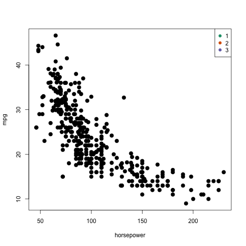

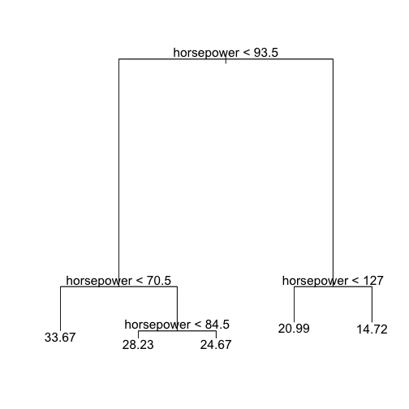

### Regression Trees

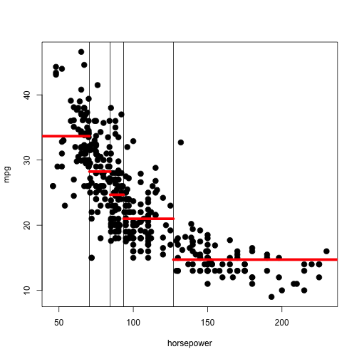

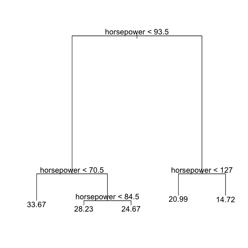

### Prediction by space partitioning

Prediction by partitioning feature (predictor) space.

1. Partition space into \( J \) non-overlapping regions, \( R_1, R_2, \ldots, R_J \).
2. For every observation that falls within region \( R_j \), predict response as mean of response for training observations in \( R_j \).

**Regression Trees create partition recursively**

### Regression Trees

1. Find predictor \( j \) and value \( s \) that minimize RSS:

\[ \sum_{i:\, x_i \in R_1(j,s))} (y_i - \hat{y}_{R_1})^2 + \sum_{i:\, x_i \in R_2(j,s))} (y_i - \hat{y}_{R_2})^2 \]

Where \( R_1 \) and \( R_2 \) are regions resulting from splitting observations on predictor \( j \) and value \( s \):

\[ R_1(j,s) = \{X|X_j < s\} \mathrm{ and } R_2(j,s) \{X|X_j \geq s\} \]

\( \hat{y}_{R_j} \) is the mean of the response \( Y \) of observations in \( R_j \).

### Regression Trees

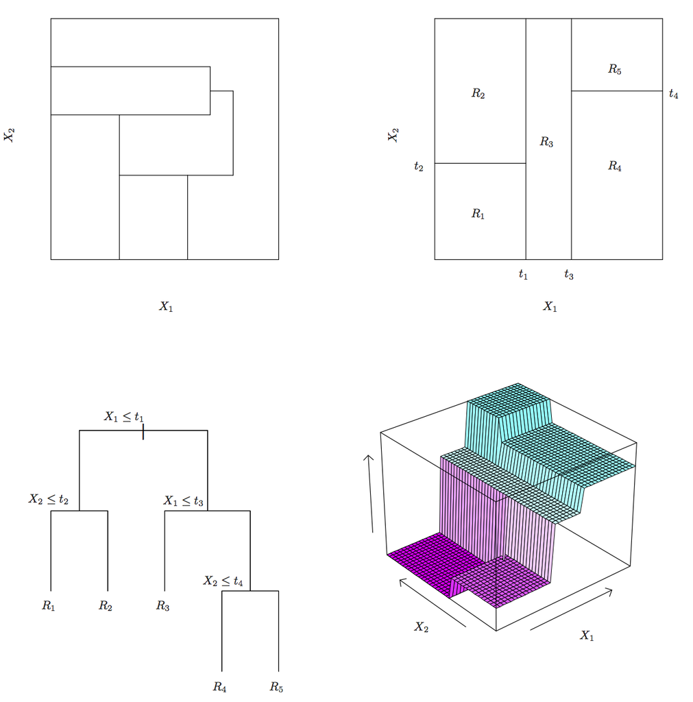

### Regression Trees

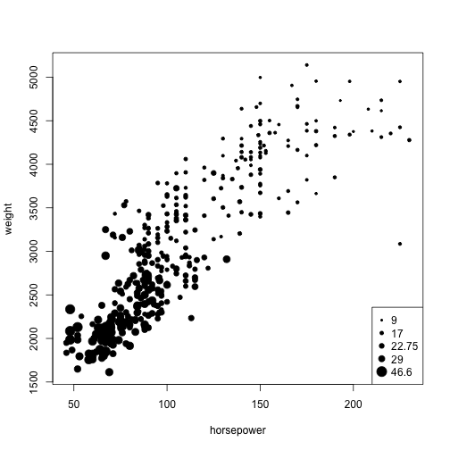

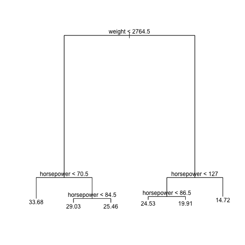

### Regression Trees

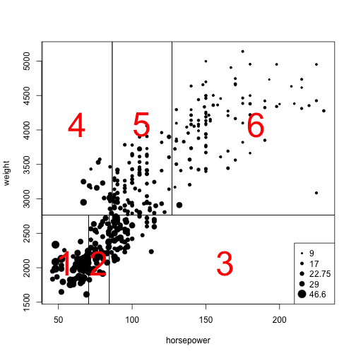

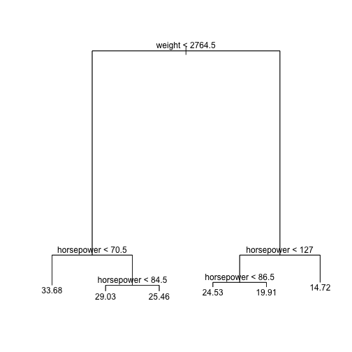

### Regression Trees

In R, built with similar interface as linear models

```r
library(tree)
library(ISLR)
data(Auto)

tree_fit <- tree(mpg~horsepower+weight, data=Auto)
predict(tree_fit)
```

### Regression Trees

- When do we stop partitioning? When adding a partition does not reduce RSS, or, when partition has too few training observations.
- Even then, trees built with this stopping criterion tend to *overfit* training data.
- To avoid this, a post-processing step called *pruning* is used to make the tree smaller:
  - **Question:** why would a smaller tree tend to generalize better?

### Pruning Regression Trees

Given a large tree \( T_0 \), *cost complexity pruning* looks for the subtree \( T_{\alpha} \) that minimizes

\[ \sum_{m=1}^{|T|} \sum_{i:\, x_i \in R_m} (y_i-\hat{y}_{R_m})^2 + \alpha |T| \]

given some positive value \( \alpha \).

How to choose \( \alpha \)? Use cross-validation to select \( \alpha \) that minimizes test-set RSS. Make \( T_{\alpha} \) the final tree.

### Pruning Regression Trees

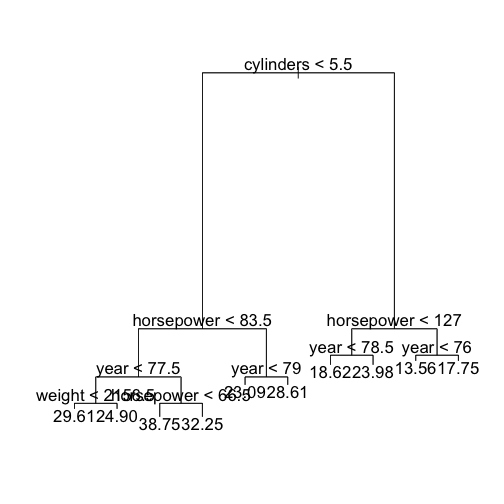

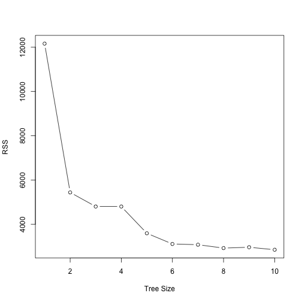

### Pruning Regression Trees

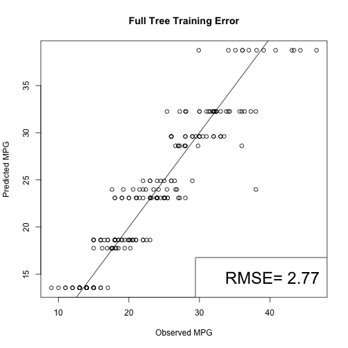

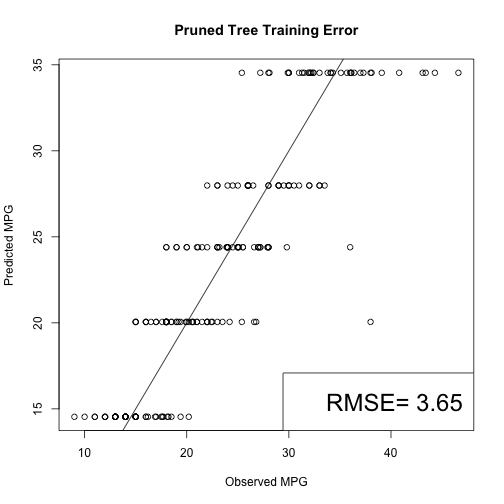

### Pruning Regression Trees

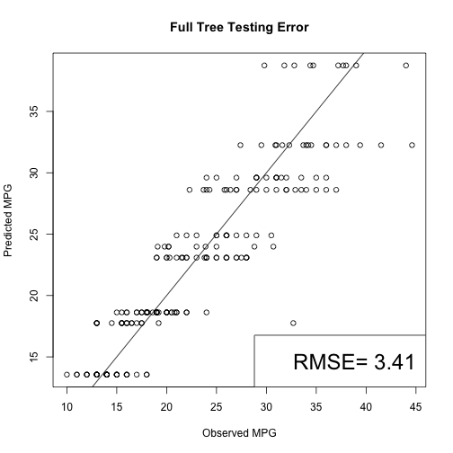

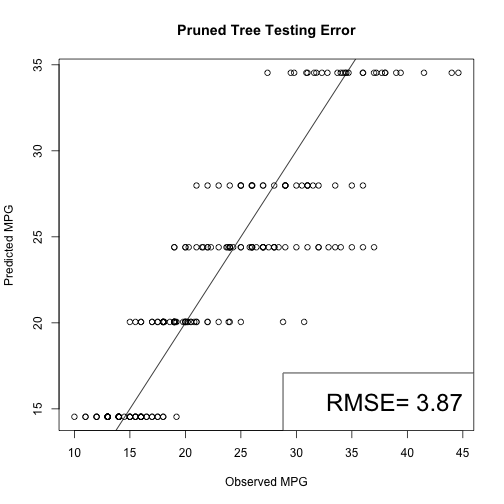

### Classification Trees

- Same partitioning principle, but now, each region predicts the majority class for training observations within region.
- Naive approach: looking for partitions that minimize training error
- Better performing approaches: look for partitions that minimize (for leaf \( m \)):
  - **Gini Index**: \( \sum_{k=1}^K \hat{p}_{mk}(1-\hat{p}_{mk}) \), or
  - **Entropy**: \( -\sum_{k=1}^K \hat{p}_{mk}\log(\hat{p}_{mk}) \)

where \( \hat{p}_{mk} \) is the proportion of training observations in partition \( m \) labeled as class \( k \).

- Both of these seek to partition observations into subsets that have the same labels.

### Classification Trees

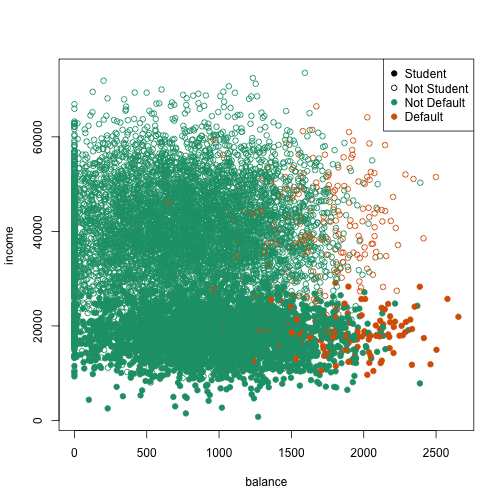

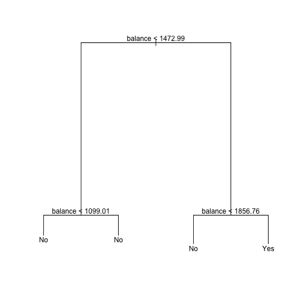

### Classification Trees

```
node), split, n, deviance, yval, (yprob)
      * denotes terminal node

1) root 10000 2921.0 No ( 0.966700 0.033300 )
  2) balance < 1472.99 9004  760.7 No ( 0.992892 0.007108 )
    4) balance < 1099.01 7085  151.2 No ( 0.998589 0.001411 ) *
    5) balance > 1099.01 1919  492.1 No ( 0.971860 0.028140 ) *
  3) balance > 1472.99 996 1162.0 No ( 0.729920 0.270080 )
    6) balance < 1856.76 786  721.0 No ( 0.828244 0.171756 ) *
    7) balance > 1856.76 210  274.9 Yes ( 0.361905 0.638095 ) *
```

### Decision Trees

Advantages

- Highly interpretable, even moreso than linear models
- Easy to visualize (if small enough)
- Maybe models human decision processes?
- No dummy predictors for categorical variables

### Decision Trees

Disadvantages

- Greedy approach via recursive partitioning
- Not always best performing (not very flexible)
- Highly unstable to changes in training data

### Random Forests

A **very popular** approach that addresses these shortcomings via resampling:

Goal is to improve prediction performance and reduce instability by *averaging* multiple decision trees (a forest constructed with randomness)

### Random Forests

First trick: *Bagging* (bootstrap aggregation) General scheme:

1. Build many decision trees \( T_1, T_2, \ldots, T_B \) from training set
2. Given a new observation, let each \( T_j \) predict \( \hat{y}_j \)
3. For regression: predict average \( \frac{1}{B} \sum_{j=1}^B \hat{y}_j \), for classification: predict with majority vote (most frequent class)

But wait, how do we get many decision trees from a single training set?

### Bootstrap

To create \( T_j, \, j=1,\ldots,B \) from training set of size \( n \):

a) create a bootstrap training set by sampling \( n \) observations from training set **with replacement** b) build a decision tree from bootstrap training set

### Bootstrap

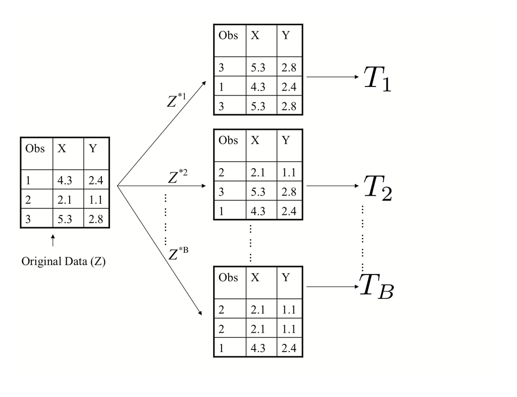

### Random Forests

Second trick: random selection of features to split!

When building each tree \( T_j \), at each recursive partition only consider a randomly selected subset of predictors to check for best split

- This reduces correlation between trees in forest, improving prediction accuracy

### Random Forests

[output not shown]